# Overlap with functional variation

TF binding sites are key determinants of transcriptional regulation, and should harbor low sequence diversity, as well as to preferentially overlap with functional variation. We examined the conservation of the TF binding regions by assessing the overall nucleotide diversity represented in the maize HapMap [1] while controlling for the overall SNP density in function to the distance of TF’s peak summit (Fig 2A). The result confirmed that sequence variation is indeed reduced, with variation decreasing in proximity of TF’s peak summit.

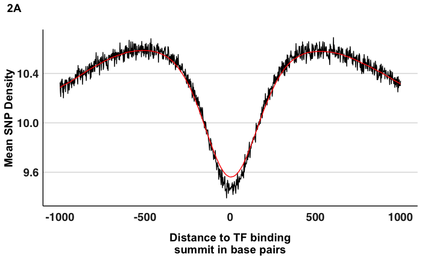

To test the global relationship between the sequence variation associated with variation in gene expression and TF binding, we calculated the statistically significance of the overlap of cis-expression QTLs [2] (hereafter eQTLs) within 2 kb of TF binding loci from the non-eQTLs SNPs (Fisher test, P-value < 0.05). Next, we quantified the enrichment of eQTLs around TF binding loci and compared with adjacent regions at least 5 kb away from the nearest TF binding loci.

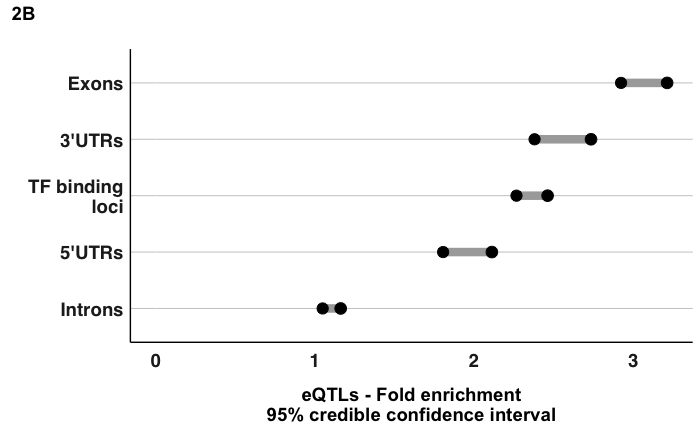

We found twofold enrichment of eQTLs around TF binding loci (95% credible interval 2.26-2.46), similar to the enrichment around 5’UTRs (95% credible interval 1.80-2.11) and 3’UTRs (95% credible interval 2.37-2.73) (Fig 2B). Furthermore, the enrichment over control regions was robust to the distance between TF binding loci and genes (Supplementary figure 5).

### Supplementary figure 5

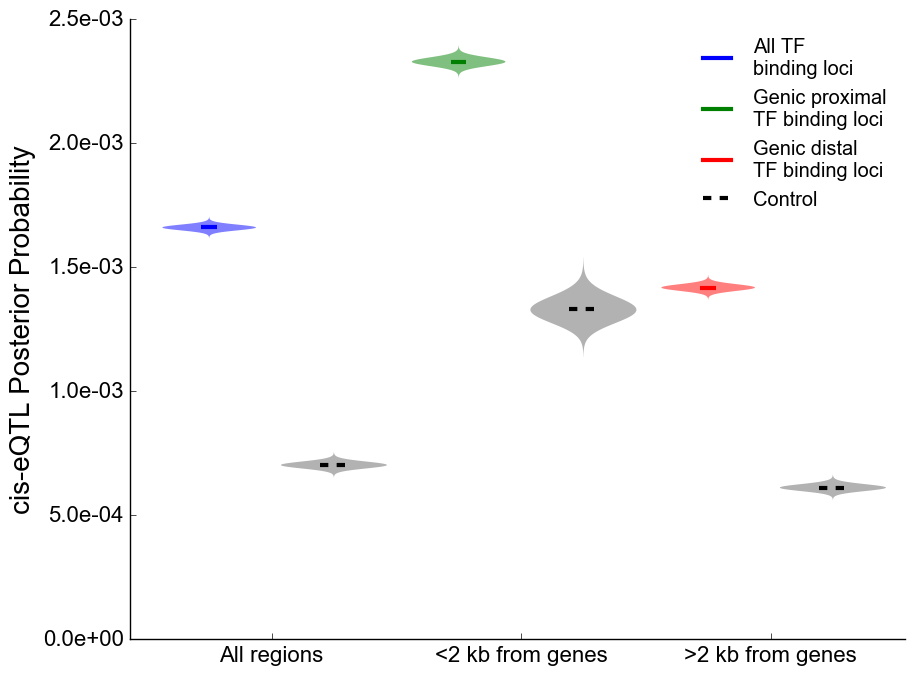

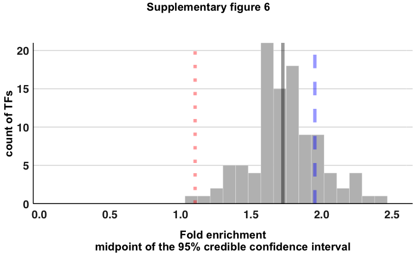

To assess the relationship between TF binding and complex trait variation, we calculated enrichment in GWAS hits for seven traits (metabolites [3], leaf architecture [4], and photoperiodicity [5]) measured in the US NAM population. We found statistical significance for the enrichment in GWAS-hits for four of the traits, including leaf angle and leaf width (Fig 2C).

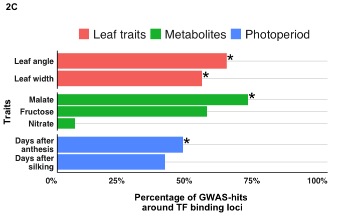

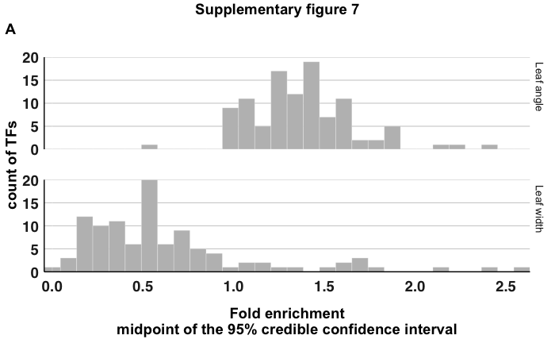

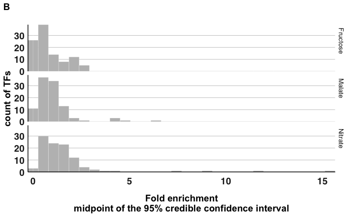

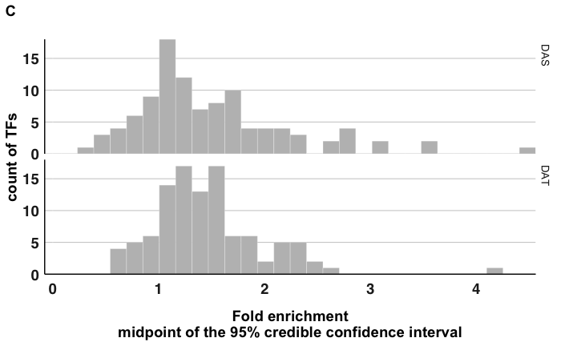

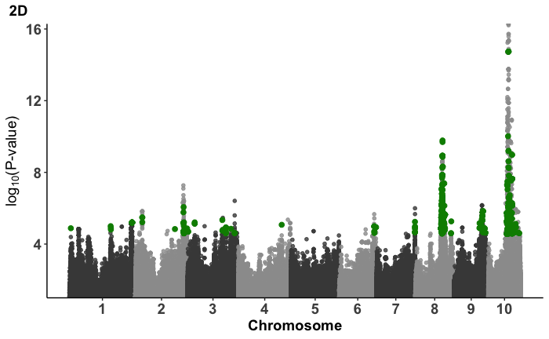

Our observation indicates that TF binding regions are conserved, and their frequent overlap with cis-eQTLs and GWAS hits suggests that TF binding regions are functional portions of the maize genome. Taken together, our finding proves the potencial of our data to connect sequence variation in cis regulatory regions to trans-regulators, and to detect functional regulatory variants implicated in complex phenotypes.

[1. Bukowski, R., Guo, X., Lu, Y., Zou, C., He, B., Rong, Z., et al. (2018). Construction of the third-generation Zea mays haplotype map. GigaScience, 7(4), 1–12.](http://doi.org/10.1093/gigascience/gix134)  
[2. Kremling, K. A. G., Chen, S.-Y., Su, M.-H., Lepak, N. K., Romay, M. C., Swarts, K. L., et al. (2018). Dysregulation of expression correlates with rare-allele burden and fitness loss in maize. Nature, 555(7697), 520–523.](http://doi.org/10.1038/nature25966)  
[3. Zhang, N., Gibon, Y., Wallace, J. G., Lepak, N., Li, P., Dedow, L., et al. (2015). Genome-wide association of carbon and nitrogen metabolism in the maize nested association mapping population. Plant Physiology, 168(2), 575–583.](http://doi.org/10.1104/pp.15.00025)  
[4. Tian, F., Bradbury, P. J., Brown, P. J., Hung, H., Sun, Q., Flint-Garcia, S., et al. (2011). Genome-wide association study of leaf architecture in the maize nested association mapping population. Nature Genetics, 43(2), 159–162.](http://doi.org/10.1038/ng.746)  
[5. Buckler, E. S., Holland, J. B., Bradbury, P. J., Acharya, C. B., Brown, P. J., Browne, C., et al. (2009). The Genetic Architecture of Maize Flowering Time. Science, 325(5941), 714–718.](http://doi.org/10.1126/science.1174276)  
[6. Salvi, S., Sponza, G., Morgante, M., Tomes, D., Niu, X., Fengler, K. A., et al. (2007). Conserved noncoding genomic sequences associated with a flowering-time quantitative trait locus in maize. Proceedings of the National Academy of Sciences, 104(27), 11376–11381.](http://doi.org/10.1073/pnas.0704145104)  
[7. Li, Y.-X., Li, C., Bradbury, P. J., Liu, X., Lu, F., Romay, C. M., et al. (2016). Identification of genetic variants associated with maize flowering time using an extremely large multi-genetic background population. The Plant Journal : for Cell and Molecular Biology, 86(5), 391–402.](http://doi.org/10.1111/tpj.13174)  
[8. Alter, P., Bircheneder, S., Zhou, L.-Z., Schlüter, U., Gahrtz, M., Sonnewald, U., & Dresselhaus, T. (2016). Flowering Time-Regulated Genes in Maize Include the Transcription Factor ZmMADS1. Plant Physiology, 172(1), 389–404.](http://doi.org/10.1104/pp.16.00285)